# Final Project Draft

Causal Inference for Computational Social Science

Author

Christy Hsu

Published

July 31, 2025

## Abstract

**July 15th**

In his 1997 article, Mark Tessler used 1988 survey data to argue that understanding popular support for Islamist movements in Arab countries requires distinguishing between Islam as personal and societal salience and the “Political Islam”. This distinction can lead us to see that attitudes toward personal and societal Islam do not necessarily align with attitudes toward political Islam. This insight challenged the prevailing assumption at the time, that support for Islamists, especially their anti-Western attitudes and actions in the news, stemmed directly from religious motives and thus an inevitable “clash of civilizations” owing to contradictory value systems. Thus, exempted attention to the socioeconomic and political grievances that has even stronger associations with the popular leaning to Islamic movements. This project hopes to begin by demonstrating how misleading impressions about political Islam may come about. An initial attempt looked to when simply equating personal religiosity with support for extending religion into the political sphere. Applying concerns from causal inference, with the 1988 survey data at hand, a preliminary analysis started by the relationship between support for political Islam, religiosity, and anti-Western attitudes. By grouping respondents by higher and lower levels of support for Islamists can induce the association of religiosity and anti-West sentiment.

## Dataset Overview and Identified Limitations

**1988 Jamal al-Suwaidi Survey Data**

This survey was carried out in mid-1988, with samples drawn from Cairo and Kuwait, targeting the urban Sunni adults: Egyptians (n = 292), Kuwaitis (n = 300) and Palestinians residing in Kuwait (n = 293).[^1]

**In Progress**

### Inquiry regarding missing sample and Request for original survey questionnaire

I first encountered the 1988 public opinion survey while reading Tessler’s *“The origins of popular support for Islamist movements: A political economy analysis (1997)”*(M. 1941.-. Tessler 1997) Later, I was able to find this dataset available on ICPSR, presented in *Carnegie Middle East Governance and Islam Dataset, 1988-2014 (ICPSR 32302)*(M. Tessler 2016) This dataset is an effort to gather surveys across the period, reorganize and harmonize the survey items into variables that allow for analysis over time. Therefore, some of survey items that Tessler used in his analysis cannot be found in the dataset, and the codebook contains limited descriptions for the 1988 survey.

As I went on to seek for further details about the 1988 survey, I came across Tessler and Grobschmidt’s study *“Democracy in the Arab world and the Arab-Israeli conflict (1995)”*.(Garnham and Tessler 1995, Mark Tessler, and Marilyn Grobschmidt. “Democracy in the Arab world and the Arab-Israeli conflict.” pp. 135-169) This earlier analysis led me to learn that the 1988 survey originally included 293 Palestinians residing in Kuwait, while the ICPSR dataset only contains the 292 Egyptian respondents and the 300 Kuwaiti respondents.[^2]

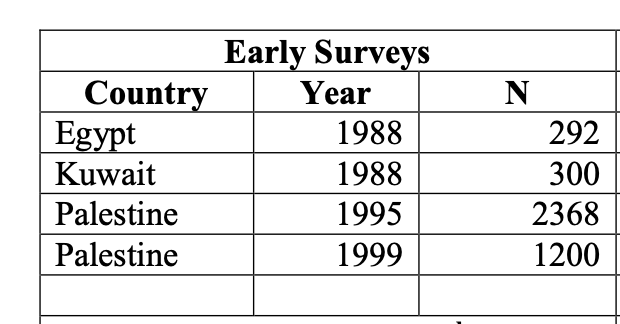

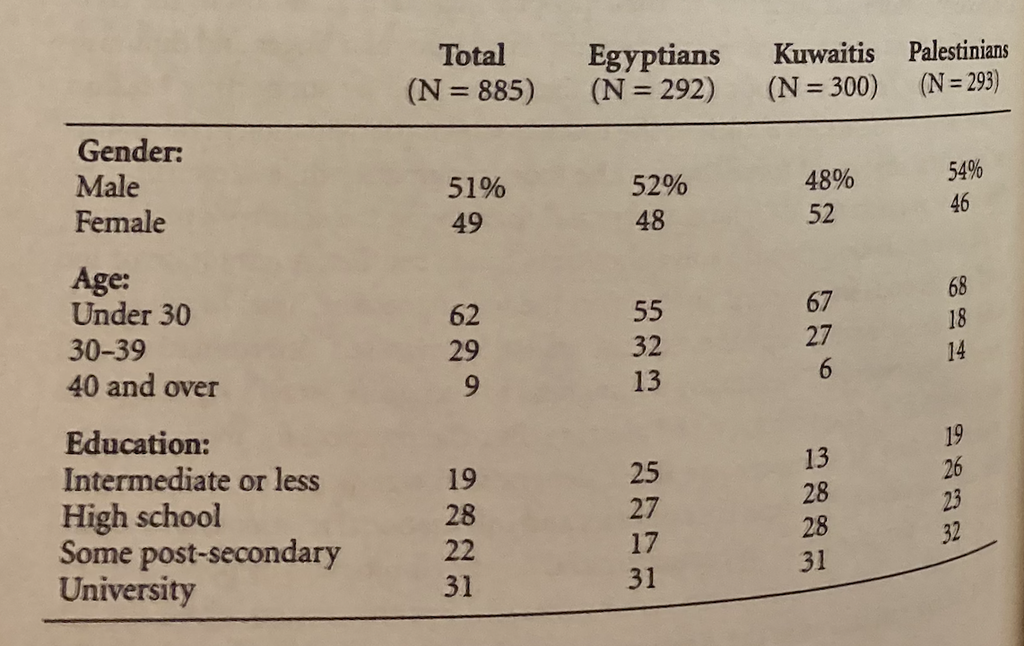

That is, although the dataset I have acquired is already fruitful, yet, relying on it alone would not allow me to replicate many analyses that were done right after 1988. And I could not convince myself not to think about why there were originally three samples originally yet I am now using only two of them because of accessibility.

Therefore, I reached out first to ICPSR. They looked over the version history and did not find any records about the 1988 Palestinian sample nor the original survey instrument. Thus, they kindly contacted Professor Tessler on my behalf. The good new today is that I received professor Tessler’s reply. In the mean time, I truly look forward to learn more about what happened with the Palestinian sample and anticipate the chance of access to the original dataset.

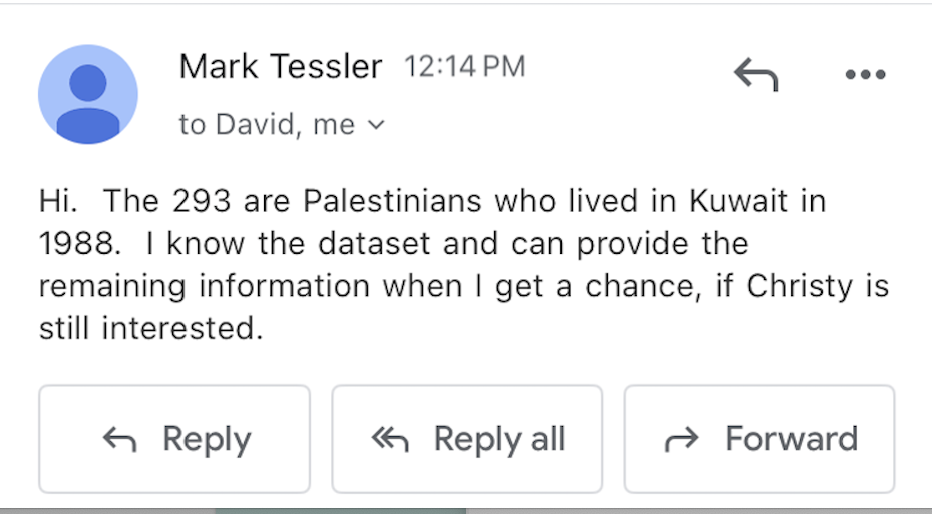

## Literature Review

This project aimed to adopt a historical approach to understand the historical topic “Islamic Revival”, “Islamic Radicalization” or “Islamic Ideology” that is central to the history of modern Middle East, or the history of Islamic Societies in the modern period.[^3]

#### How Historians talk about Islamism

#### How Social Scientists talk about Islamism

**Coarse-to-Fine Examination of Islamist Movements**

1. Why Islamic Revolution happened in Iran? State-level analysis, comparison.
2. Steven Brooke and Neil Ketchley “Social and Institutional Origins of Political Islam”: the spread and the distribution of Muslim Brotherhood branches in the Interwar (1937-1945) Egypt(Brooke and Ketchley 2018)
3. “Popular Support”: who are the ordinary muslims that support for political islam, and what individual characteristics or circumstances leading them to certain perception of Islamist group, to join Islamist movement and to agreement with Islamic Ideologies?(M. 1941.-. Tessler 1997)

## Dependent Variable and Independent Variable

### Dependent Variable

On what basis can we talk about an “Islamic Revival”, “Islamic Radicalization”? What evidence can allow us to indicate an emerging support for political Islam from the mass in the 1980s? Or, what takes us to arrive at saying the success or failure of Political Islam?(Roy 1994, the just Ummah didn’t come accordingly)

- Tracing the genealogy of “Islamic Ideology”, for example, adopting Dabashi’s broad definition, we can count from Jamal al-Din al-Afghani (1838-1897)(Dabashi, n.d.)
- Muslim Brotherhood membership statistics, and the various attempts from the state to oppress can be seen as evidence of their presence that was intolerable.
- The most direct evidence probably is that the Islamist, or the Islamic political parties were doing well in elections.(Krennerich, Nohlen, and Thibaut 1999)
  - 1992 Ramallah election for Chamber of Commerce, PLO defeated by Hamas(Ibrahim 1992)
- A particular survey item, or a set of survey items.

### Predictor/Predictors

- Individual:
  - Religiosity (personal and societal Islam)
  - Anti-West
- Country-Level:
  - government form

### Covariates

- The survey project designed to concentrate on “urban, adult, Sunni Muslim”, which helped us reduce some covariates that would need to take into account, at the same time reflected the particular concerns and assumptions of the research[^4]
- demographics

### The Estimands

Latent: this project would want to have estimates and express our degrees of confidence for regression coefficients, given our data

## Approaches

### To begin with

1. Cross tabulation
2. Linear Regression (categorical survey variables: probit, logit regression for binary regression/chisq test)

### Next

3. Multivariate: Bayes net, graphical representation
4. Bayesian Workflow(Gelman et al. 2013)

**Tip**

Priors for pre-treatment variables - incorporate contextual information Priors for variables of interest

Sampling Distribution - We have relatively small samples, historical records can help us to evaluate our confidence toward the representativeness of our sampling distribution

## Messages

The main messages that I hope this project (an attempt to model the support for Political Islam in the late 1980s using PGM) can bring about:

Counter the progress-west and backward-east artifact.

Islamist movements that reflects the diversity of the communities.

The complicated relationship between modernization and Islamism, to see it not as a departure of the modernization process, but as a creative response to modernity and some of the strongest critics of the modern West.

The real bitterness and predicaments of modern middle east, recognize the responsibilities the West bears in contributing.

**latex pgm (practicing)**

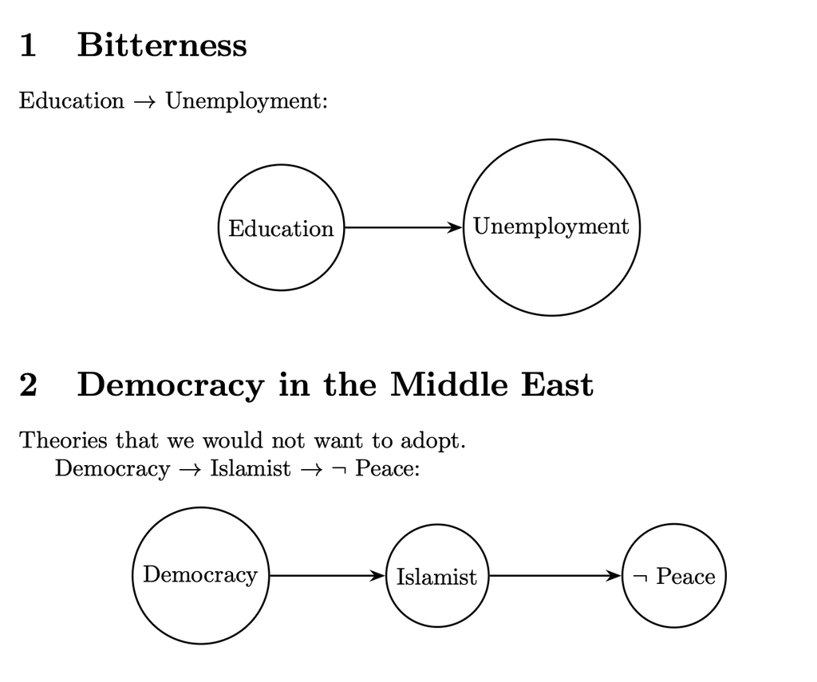

**from the writings of key thinkers (in progress)**

In the third quarter of the 19th century, people looked to Islam for a solution in order to deal with the encounter of the decentralized and diverse Ottoman empire to the unified and militant western modern nation states. One case we can look to is Jamal al-Din al-Afghani. In his writing “Plan for Islamic Unity” in 1884, al-Afghani advocated for the Islam states to reunite as he treated Islam as a civilization, he anticipated that once this unity of Muslims established, they will gain enough strength to counter the European imperialism that was at the time taking an interest in the Muslim world. Therefore, this approach to Islam was an instrumental and political one, much because of a sense of existential threat that Muslims might no longer be able to rule themselves. It is worth noting that, al-Afghani’s calling for modernizing Islam and for unifying the Muslims, that call implies that “Islam”, the Muslims and the Islamic community at the late 19th century were all on the far side of being unified. The diversity in the Ottoman Empire and in the religion itself was the reality of the late 19th century. We can see that in the view of al-Afghani, their immediate problem was about the community of this world, thus, he borrowed concepts from the west trying to foment a unity in the sense, he supported the military reform. His attitude can also be observed in his cooperation with Ottoman Sultan Abdulhamid II in promoting pan-Islamism, expecting to add on to the integrity and the strength of the Ottoman Empire. Al-afghani’s Islam revival has much to do with societal and political problems rather than the religion itself. The ultimate goal of this movement or of pan-Islamism was to reclaim strength for the Muslim world. This aligns with the 19th century modernizing reforms carried out by the Ottoman Sultan, but also a reflection on why modernizing and westernizing was taking place but the empire was still disintegrating.

## References

Brooke, Steven, and Neil Ketchley. 2018. “Social and Institutional Origins of Political Islam.” *American Political Science Review* 112 (2): 376–94.

Dabashi, Hamid. n.d. *Theology of Discontent: The Ideological Foundatation of the Islamic Revolution in Iran*. Transaction Publishers.

Garnham, David, and Mark A. Tessler. 1995. *Democracy, War, and Peace in the Middle East*. Indiana Series in Arab and Islamic Studies. Bloomington, IN: Indiana University Press.

Gelman, Andrew, John B. Carlin, Hal S. Stern, David B. Dunson, Aki Vehtari, and Donald B. Rubin. 2013. *Bayesian Data Analysis, Third Edition*. CRC Press.

Ibrahim, Youssef M. 1992. “P.L.O. Is Facing Growing Discontent.” *The New York Times*, April.

Krennerich, Michael, Dieter Nohlen, and Bernhard Thibaut. 1999. *Elections in Africa: A Data Handbook*. Oxford ; Oxford University Press.

Roy, Olivier. 1994. *The Failure of Political Islam*. London: I.B. Tauris.

Tessler, Mark. 2016. “Carnegie Middle East Governance and Islam Dataset, 1988-2014.” Inter-university Consortium for Political and Social Research. https://doi.org/10.3886/ICPSR32302.v6.

Tessler, Mark 1941-. 1997. “The Origins of Popular Support for Islamist Movements: A Political Economy Analysis.” *Islam, Democracy, and the State in North Africa*, 93.

## Footnotes

[^1]: ICPSR 32302 codebook, Garnham and Tessler (1995), pp. 164-166. Namely, Kuwaiti Shii muslims, Egyptian Christians and Palestinian Christians were excluded.
[^2]: and in 1992 Tessler had already finished writing his research “The Origin of Popular Support for Islamist movements” as a part of a research project launched by USAID, yet, it was till 1997 that the paper was rewritten and published
[^3]: the “Modern” Middle East, for analytical purpose, is commonly agreed to have begun with Napoleon’s invasion of Egypt in 1798
[^4]: which, analyses often took this particular group of respondents as Arabs